# Part 1 - R introduction

Simon says:

- **learn is hard**: remember all the hours learning biology concepts;
- **be patient and practise**: remember your experiments rarely success with your first attempt;
- **use fresh eyes**: do not try to compare (yes, there is similarity with Excel or other); adopt the foreign language/culture learning process;
- **be organised**: apply your experimental methodologies to your computational analysis; track your work with a *digital* **lab notebook**, e.g., with RMardown files. ;-)

In this introduction to R, we will present the main R concepts, by introducing R variables, vectors, matrices, lists, functions and packages.

Please read http://adv-r.had.co.nz/Style.html.

# Variable

In R, we have two main types of values: numeric values and characters. Numerics:

```r
12
```

```
## [1] 12
```

```r
3.14
```

```
## [1] 3.14
```

```r
-42.12
```

```
## [1] -42.12
```

and characters:

```r
"text"
```

```
## [1] "text"
```

```r
"Rock and Roll"
```

```
## [1] "Rock and Roll"
```

The characters also named strings are between double-quote `"` (french keyboard: key 3).

We can save these values in variables,

```r
a <- 3.14
```

so we can easily access them later or re-use them:

```r
a + a
```

```
## [1] 6.28
```

```r
a
```

```
## [1] 3.14
```

We can compute, save the value and display it:

```r
result <- 2*a + 3 * pi
result
```

```
## [1] 15.70478
```

### Exercises

1. Assign a number of your choice to the variable `b`
2. Show what’s in `b`
3. Multiply `a` by `2`
4. Add `10` to `a`
5. Assign your name to an object called name

# Vector / List

Vector contains several values:

```r
b <- 1:10
```

We can concatenate these values with the `c()` function:

```r
c(b, b)
```

```
##  [1]  1  2  3  4  5  6  7  8  9 10  1  2  3  4  5  6  7  8  9 10
```

We can also apply mathematical formulas to them:

```r
b + b
```

```
##  [1]  2  4  6  8 10 12 14 16 18 20
```

```r
3 * b
```

```
##  [1]  3  6  9 12 15 18 21 24 27 30
```

### Exercises

6. Concatenate `a` and `b`
7. Concatenate your name and `a`
8. Add `a` to `b`

# Built-in Function

Many functions exist in R, and greatly simplify our life.

How to compute the mean of the variable `b` ? The naive way:

```r
(1 + 2 + 3 + 4 + 5 + 6 + 7 + 8 + 9 + 10)/10
```

```
## [1] 5.5
```

And now, what does it happen if `b <- 5:17`? We have to modify the formula. Not enough powerful. R has built-in functions to easily compute common quantities.

For example, the mean is computed by:

```r
mean(b)
```

```
## [1] 5.5
```

Moreover, we can compose the function and the mathematical operations (also fucntion).

```r
m <- mean(b + b)
m
```

```
## [1] 11
```

What about the median? Easy:

```r
median(b)
```

```
## [1] 5.5
```

And the number of elements (the length of the vector/list):

```r
length(b)
```

```
## [1] 10
```

```r
length(b + b)
```

```
## [1] 10
```

```r
length(c(b, b))
```

```
## [1] 20
```

The concatenation `c()` is a built-in function.

Let sum all the elements, find the minimum, the maximum:

```r
sum(b)
```

```
## [1] 55
```

```r
min(b)
```

```
## [1] 1
```

```r
max(b)
```

```
## [1] 10
```

Or print a statistical summary:

```r
summary(b)
```

```
##    Min. 1st Qu.  Median    Mean 3rd Qu.    Max.
##    1.00    3.25    5.50    5.50    7.75   10.00
```

List the 6 first elements:

```r
head(b)
```

```
## [1] 1 2 3 4 5 6
```

or the 6 last:

```r
tail(b)
```

```
## [1]  5  6  7  8  9 10
```

or the 4 last:

```r
tail(b, n=4)
```

```
## [1]  7  8  9 10
```

Be careful, R does not warn even if we are asking *weird* stuff:

```r
head(b, n=20)
```

```
##  [1]  1  2  3  4  5  6  7  8  9 10
```

We can read help using:

```r
?tail
```

or the Help facilities of RStudio.

### Exercises

9. Create the vector 13, 13, 13, 13, 14, 14, 16, 18, 21 and asign it to a variable:
10. Compute the median:
11. Compute the mean:
12. Is it normal? ;-)
13. Compute the length:
14. Sum all the values:
15. Compute the mean using the previous sum and length

# Block (chunk) with comment

We sometimes want to insert a comment to remind the purpose of an action.

A comment starts with the symbol sharp `#`.

```r
# this is a comment
```

and a comment does nothing when evaluated.

It is really useful to explain several lines:

```r
# Assign a list from 10 to 25 to the variable named var
var <- 10:25

# Select first elements
head(var)
```

```
## [1] 10 11 12 13 14 15
```

```r
var + var # return a new list
```

```
##  [1] 20 22 24 26 28 30 32 34 36 38 40 42 44 46 48 50
```

```r
# Eval the length the concatenated list
length(c(var, var))
```

```
## [1] 32
```

The comments do not appear in the Output block. However they appear in the final document (see this doc).

# Matrices / Table

Matrices can be compared to tables: they are two dimensional and can contain numbers, characters, etc.

Let load a matrix:

```r
load("cyto.RData")
cyto
```

```
##             FSC-A     SSC-A      CD45      CD19      CD34      CD56
## cell_1   96985.98  34853.85 160.62489 111.52325  60.59250  75.91315
## cell_2   88143.30  22730.01 146.89993 109.37424  60.74403  66.13155
## cell_3   92953.35  31651.34  46.90078  64.03857  76.36395  82.21494
## cell_4   78595.02  51510.99 176.39761  63.25624  64.01659 114.98014
## cell_5  109199.79  60020.60 159.90495  63.29745  87.70644  88.29176
## cell_6  136586.52 130294.78 162.73160  59.74005  88.22612 140.49802
## cell_7   86250.78  25582.85  14.60138  63.21502  78.34427  65.37292
## cell_8    6391.98   4621.63  99.39405  58.45350  55.43047  65.70305
## cell_9   16286.76   7108.74 101.62800  67.55399 148.54910  77.11388
## cell_10  91409.22  76663.14 195.31946  59.94742  79.83633  80.57721
```

We can check the number of rows and columns in the cyto object:

```r
nrow(cyto)
```

```
## [1] 10
```

```r
ncol(cyto)
```

```
## [1] 6
```

```r
dim(cyto)
```

```
## [1] 10  6
```

Load data from CSV file and show a summary:

```r
df <- read.csv2(file='example.csv', header=TRUE, dec=",", sep=";")
dim(df)
```

```
## [1] 150   5
```

```r
summary(df)
```

```
##       Var1            Var2            Var3            Var4
##  Min.   :4.300   Min.   :2.000   Min.   :1.000   Min.   :0.100
##  1st Qu.:5.100   1st Qu.:2.800   1st Qu.:1.600   1st Qu.:0.300
##  Median :5.800   Median :3.000   Median :4.350   Median :1.300
##  Mean   :5.843   Mean   :3.057   Mean   :3.758   Mean   :1.199
##  3rd Qu.:6.400   3rd Qu.:3.300   3rd Qu.:5.100   3rd Qu.:1.800
##  Max.   :7.900   Max.   :4.400   Max.   :6.900   Max.   :2.500
##          Pop
##  setosa    :50
##  versicolor:50
##  virginica :50
##
##
##
```

# Indexing

We can display the element in the first row and the first column, or the 2nd row and 3rd column.

```r
cyto[1, 1]
```

```
## [1] 96985.98
```

```r
cyto[2, 3]
```

```
## [1] 146.8999
```

The indexing convention is: row, column.

All the elements of a specific column of a matrix can be selected by its number, here the 3rd column:

```r
fcs_a <- cyto[, 3]
fcs_a
```

```
##    cell_1    cell_2    cell_3    cell_4    cell_5    cell_6    cell_7
## 160.62489 146.89993  46.90078 176.39761 159.90495 162.73160  14.60138
##    cell_8    cell_9   cell_10
##  99.39405 101.62800 195.31946
```

How to concatenate two columns ?

```r
# 1. select column 2 and column 5
# 2. concatenate them
# 3. store in the variable
fcs_b <- c(cyto[, 2], cyto[, 5])
fcs_b
```

```
##       cell_1       cell_2       cell_3       cell_4       cell_5
##  34853.85156  22730.00977  31651.34180  51510.99219  60020.60156
##       cell_6       cell_7       cell_8       cell_9      cell_10
## 130294.78125  25582.85156   4621.62988   7108.74023  76663.14062
##       cell_1       cell_2       cell_3       cell_4       cell_5
##     60.59250     60.74403     76.36395     64.01659     87.70644
##       cell_6       cell_7       cell_8       cell_9      cell_10
##     88.22612     78.34427     55.43047    148.54910     79.83633
```

```r
# 1. concatenate the number 2 and 5
# 2. select the columns 2 and 5
# 3. store
fcs_c <- cyto[, c(2, 5)]
fcs_c
```

```
##             SSC-A      CD34
## cell_1   34853.85  60.59250
## cell_2   22730.01  60.74403
## cell_3   31651.34  76.36395
## cell_4   51510.99  64.01659
## cell_5   60020.60  87.70644
## cell_6  130294.78  88.22612
## cell_7   25582.85  78.34427
## cell_8    4621.63  55.43047
## cell_9    7108.74 148.54910
## cell_10  76663.14  79.83633
```

```r
# Do you see the difference ?
```

The column can also be selected by typing its column name directly:

```r
cd45 <- cyto[, "CD34"]
cd45
```

```
##    cell_1    cell_2    cell_3    cell_4    cell_5    cell_6    cell_7
##  60.59250  60.74403  76.36395  64.01659  87.70644  88.22612  78.34427
##    cell_8    cell_9   cell_10
##  55.43047 148.54910  79.83633
```

```r
cd45_b <- cyto[, 5]
cd45_b
```

```
##    cell_1    cell_2    cell_3    cell_4    cell_5    cell_6    cell_7
##  60.59250  60.74403  76.36395  64.01659  87.70644  88.22612  78.34427
##    cell_8    cell_9   cell_10
##  55.43047 148.54910  79.83633
```

Idem to select several columns:

```r
cd45_c <- cyto[, c("CD34", "CD45")]
cd45_c
```

```
##              CD34      CD45
## cell_1   60.59250 160.62489
## cell_2   60.74403 146.89993
## cell_3   76.36395  46.90078
## cell_4   64.01659 176.39761
## cell_5   87.70644 159.90495
## cell_6   88.22612 162.73160
## cell_7   78.34427  14.60138
## cell_8   55.43047  99.39405
## cell_9  148.54910 101.62800
## cell_10  79.83633 195.31946
```

However, you cannot mix number and name to select columns. This chunk returns an error:

```r
# cyto[, c(1, "CD34")]
```

Conversely, we can select a specific row, here the second:

```r
cell2 <- cyto[2, ]
cell2
```

```
##       FSC-A       SSC-A        CD45        CD19        CD34        CD56
## 88143.29688 22730.00977   146.89993   109.37424    60.74403    66.13155
```

## Important to remember

- The names are important.
- The spaces in column name are hell.

**Good names** of variables, columns, files, etc. **ease a lot** the analysis, especially when things are not going as expected.

### Exercises

16. Show the 2 first rows of the cyto matrix
17. Show the `FSC-A` value of the first cell

# More on list

Lists in R can be compared to vectors, which can contain various objects:

```r
random_numbers <- c(1, 2, 3, 7)
random_letters <- c("A", "B", "C", "Z")
```

The variables `random_numbers` and `random_letters` are two lists containing 4 numbers or 4 letters.

These two lists can be associated to create another list:

```r
my_list_b <- list(random_letters, random_numbers)
my_list_b
```

```
## [[1]]
## [1] "A" "B" "C" "Z"
##
## [[2]]
## [1] 1 2 3 7
```

The variable `my_list_b` is a list containing two sub-lists. These sub-lists can be named:

```r
my_list <- list(my_numbers = random_numbers,
                my_letters = random_letters)
my_list
```

```
## $my_numbers
## [1] 1 2 3 7
##
## $my_letters
## [1] "A" "B" "C" "Z"
```

The different items of a list can then be accessed by using the `$` and typing their name directly:

```r
my_list$my_numbers
```

```
## [1] 1 2 3 7
```

### Exercises

18. Create a list containing your name, and job:

# Packages

Packages contain sets of useful functions, which can be installed, loaded, and then used in R. A package needs to be installed only once on your computer:

```r
#install.packages("Rtsne")
```

But needs to be loaded every time you wish to use it:

```r
#library(Rtsne)
```

The functions of an installed package can then be used. They often need the user to set parameters:

```r
#tsne <- Rtsne(cyto)
```

This line would generate an error, we need to lower the perplexity as we only have 10 cells.

```r
#tsne <- Rtsne(cyto, perplexity = 2)
#tsne$Y
```

You can always ask help to R, if you wish to know how a function works:

```r
#?Rtsne
```

# Define your own function

It is easy to define new functions. For example, I redefine my way to compute the mean:

```r
moyenne <- function(lst) {
  sumall <- sum(lst)
  len <- length(lst)
  moy <- sumall / len
  moy
}
```

Then I can use it:

```r
onelist <- 1:10
moyenne(onelist)
```

```
## [1] 5.5
```

and the result is the same than `mean(onelist)` i.e., 5.5.

It is out of this presentation, but R is powerful and you can write loops over list, test value, etc.

```r
moyenne.absolute <- function(lst) {
  # init temporary variables
  nelem <- 0
  tot <- 0
  # loop over all the elements of the list
  for (val in lst) {
    if (val > 0 ) {
      tot <- tot + val
    } else {
      tot <- tot - val
    }
    nelem <- nelem + 1
  }
  # compute something
  moy <- tot / nelem
  # return it
  moy
}
```

and this function computes `mean(abs(lst))`. Let check that:

```r
one <- 1:10
onelist <- c(-one, 2*one)

moyenne.absolute(onelist) == mean(abs(onelist))
```

```
## [1] TRUE
```

Well, if this section is not clear for you, then do not worry. We will talk again later.

# RMarkdown summary

- list starts with `-`
- *italics* is `*italics*`
- **bold** is `**bold**`
- `code` is `` `code` ``
- equation $E=mc^2 + \sum x_i$ is `$E=mc^2 + \sum x_i$`
- section starts with `#`, subsection with `##`, subsubsubsection with `###`, etc.
- [hyperlink](https://www.rstudio.com/wp-content/uploads/2016/03/rmarkdown-cheatsheet-2.0.pdf) is `[hyperlink](https://www.rstudio.com/wp-content/uploads/2016/03/rmarkdown-cheatsheet-2.0.pdf)`

## Subsection talking about table

You can also pretty print, e.g., a table:

Legend of the cyto table

|  | CD45 | CD34 | CD56 |
| --- | --- | --- | --- |
| cell_3 | 46.90078 | 76.36395 | 82.21494 |
| cell_4 | 176.39761 | 64.01659 | 114.98014 |
| cell_5 | 159.90495 | 87.70644 | 88.29176 |
| cell_6 | 162.73160 | 88.22612 | 140.49802 |
| cell_7 | 14.60138 | 78.34427 | 65.37292 |

### Subsubsection talking about figure

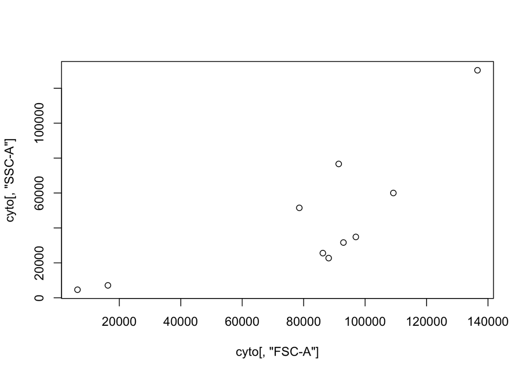

My nice caption of my nice figure

# Further readings

You could also have a look at the following online resources:

- https://rmarkdown.rstudio.com/lesson-1.html
- https://www.rstudio.com/online-learning/#r-programming
- https://www.youtube.com/watch?v=o0Y478jOjGk (11min29)
- https://www.youtube.com/watch?v=u1r5XTqrCTQ (2min52)

Please read http://adv-r.had.co.nz/Style.html.